# Bed-1304 Python lab

Seminar 5 - Pandas og databehandling

## Last ned seminaroppgavene

Gå inn på canvas eller uit-bed-1304-h25.github.io og finn “Oppgaver”

Last ned “Seminar5_Pandas_og_databehandling.ipynb”

## Oppgave 1: Opprette en Pandas DataFrame

Opprett en DataFrame som inneholder informasjon om tre forskjellige produkter:

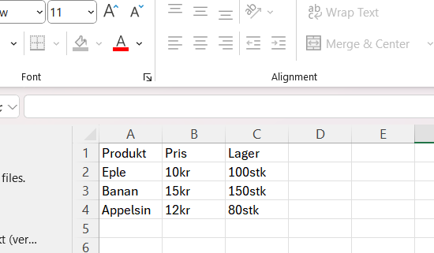

**Kolonner**: “Produkt”, “Pris”, “Lager”

**Data**:

- “Eple”, 10 kr, 100 stk
- “Banan”, 15 kr, 150 stk
- “Appelsin”, 12 kr, 80 stk

Skriv ut hele DataFrame-en.

## 1 Gjennomgang

```python
import pandas as pd # Hvis error skriv %pip install pandas først

# Opprett en dictionary med data
data = {
    "Produkt": ["Eple", "Banan", "Appelsin"],
    "Pris i kroner": [10, 15, 12],
    "Lager i antall": [100, 150, 80]
}

# Lag en DataFrame fra dictionaryen
df = pd.DataFrame(data)

# Skriv ut DataFrame
print(df)
```

```
    Produkt  Pris i kroner  Lager i antall
0      Eple             10             100
1     Banan             15             150
2  Appelsin             12              80
```

## Oppgave 2: Filtrere Data i en DataFrame

Bruk DataFrame-en fra Oppgave 1.

Finn og skriv ut alle produkter med en pris over 12 kr.

### Eksempel finner de under 30 år

```python
personer = {
    "Navn": ["Per", "Pål", "Ola"],
    "Høyde": [180, 175, 170],
    "Alder": [30, 25, 35]
}
personer_df = pd.DataFrame(personer)
aldre_under_30 = personer_df[personer_df["Alder"] < 30]
print(aldre_under_30)
```

```
  Navn  Høyde  Alder
1  Pål    175     25
```

## 2 Gjennomgang

```python
# Filtrer produkter med pris over 12 kr
dyre_produkter = df[df["Pris i kroner"] > 12]
print(dyre_produkter)
```

```
  Produkt  Pris i kroner  Lager i antall
1   Banan             15             150
```

## Oppgave 3: Legge til en Ny Kolonne

Legg til en ny kolonne `Total verdi` i DataFrame-en. Den skal vise **pris × lager** for hvert produkt.

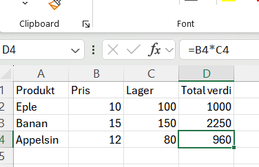

### Eksempel med vekst per år

```python
personer_df["Vekst per år"] = personer_df["Høyde"] / personer_df["Alder"]
print(personer_df)
```

```
  Navn  Høyde  Alder  Vekst per år
0  Per    180     30      6.000000
1  Pål    175     25      7.000000
2  Ola    170     35      4.857143
```

## 3 Gjennomgang

```python
# Legg til en ny kolonne som heter 'Total verdi'
df["Total verdi"] = df["Pris i kroner"] * df["Lager i antall"]

# Skriv ut oppdatert DataFrame
print(df)
```

```
    Produkt  Pris i kroner  Lager i antall  Total verdi
0      Eple             10             100         1000
1     Banan             15             150         2250
2  Appelsin             12              80          960
```

## Oppgave 4: Laste Inn Data fra en CSV-fil

Last inn csv-filen ved å trykke på “her” eller skrive inn linken her https://github.com/uit-bed-1304-h25/uit-bed-1304-h25.github.io/tree/main/data

Print ut de første fem radene av dataene ved hjelp av funksjonen `df.head()`.

```python
# Les inn CSV-fil
df_student = pd.read_csv("StudentPerformanceFactors.csv")
#Eventuelt
df_student = pd.read_csv("https://raw.githubusercontent.com/uit-bed-1304-h25/uit-bed-1304-h25.github.io/refs/heads/main/data/StudentPerformanceFactors.csv")

# Vis de første radene
df_student.head()
```

## 4 Gjennomgang

```python
# Les inn CSV-fil
df_student = pd.read_csv("https://raw.githubusercontent.com/uit-bed-1304-h25/uit-bed-1304-h25.github.io/refs/heads/main/data/StudentPerformanceFactors.csv")

# Vis de første radene
df_student.head()
```

|  | Hours_Studied | Attendance | Parental_Involvement | Access_to_Resources | Extracurricular_Activities | Sleep_Hours | Previous_Scores | Motivation_Level | Internet_Access | Tutoring_Sessions | Family_Income | Teacher_Quality | School_Type | Peer_Influence | Physical_Activity | Learning_Disabilities | Parental_Education_Level | Distance_from_Home | Gender | Exam_Score |
| --- | --- | --- | --- | --- | --- | --- | --- | --- | --- | --- | --- | --- | --- | --- | --- | --- | --- | --- | --- | --- |
| 0 | 23 | 84 | Low | High | No | 7 | 73 | Low | Yes | 0 | Low | Medium | Public | Positive | 3 | No | High School | Near | Male | 67 |
| 1 | 19 | 64 | Low | Medium | No | 8 | 59 | Low | Yes | 2 | Medium | Medium | Public | Negative | 4 | No | College | Moderate | Female | 61 |
| 2 | 24 | 98 | Medium | Medium | Yes | 7 | 91 | Medium | Yes | 2 | Medium | Medium | Public | Neutral | 4 | No | Postgraduate | Near | Male | 74 |
| 3 | 29 | 89 | Low | Medium | Yes | 8 | 98 | Medium | Yes | 1 | Medium | Medium | Public | Negative | 4 | No | High School | Moderate | Male | 71 |
| 4 | 19 | 92 | Medium | Medium | Yes | 6 | 65 | Medium | Yes | 3 | Medium | High | Public | Neutral | 4 | No | College | Near | Female | 70 |

## Oppgave 5: Finn Gjennomsnittlig Eksamensscore

Bruk `Pandas` til å finne **gjennomsnittlig eksamensscore** for hele datasettet.

## 5 Gjennomgang

```python
# Finn gjennomsnittlig eksamensscore
gj_snitt = df_student["Exam_Score"].mean()

print(f"Gjennomsnittlig eksamensscore er {gj_snitt:.2f}")
```

```
Gjennomsnittlig eksamensscore er 67.24
```

## Oppgave 6: Tell Antall Elever med og uten Internett

Bruk Pandas til å finne ut hvor mange elever som har tilgang til internett og hvor mange som ikke har det. Da vil du ha bruk for funksjonen `value_counts` til Pandas.

## 6 Gjennomgang

```python
# Tell hvor mange elever som har tilgang til internett
internett_tilgang = df_student["Internet_Access"].value_counts()

print(internett_tilgang)
```

```
Internet_Access
Yes    6108
No      499
Name: count, dtype: int64
```

Vis hvor mange elever som går på **Public** vs. **Private** skoler ved hjelp av et stolpediagram.

## 7 Gjennomgang

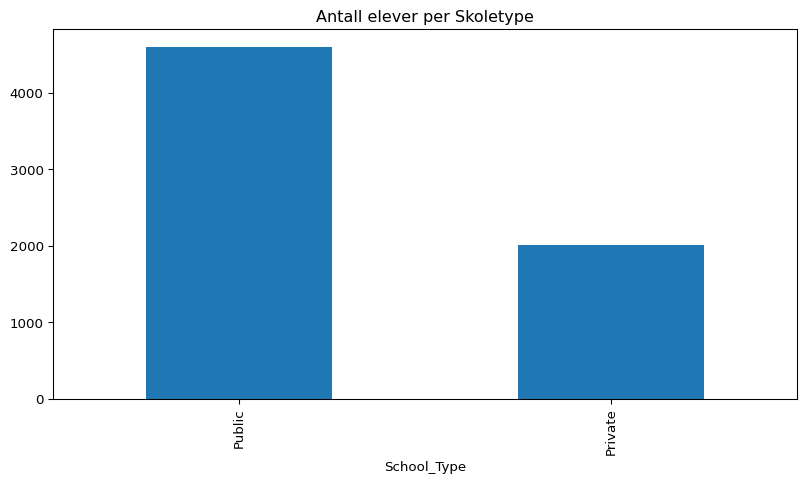

```python
# Lag et stolpediagram over skoletyper
df_student["School_Type"].value_counts().plot(kind="bar", title="Antall elever per Skoletype")
```

## Oppgave 8 a b og c: Utforsk Dataene med Pandas

I denne oppgaven skal du bruke Pandas’ innebygde metoder for å undersøke datasettet om studentenes og deres vaner.

### a) Sjekk informasjon om datasettet

Bruk Pandas til å vise en oversikt over kolonner, datatyper og manglende verdier. .info()

### b) Vis de første 5 radene i datasettet

Se hvordan dataene ser ut ved å hente ut de første radene.

### c) Finn antall rader og kolonner

Bruk Pandas for å finne ut hvor mange rader og kolonner datasettet inneholder.

## Gjennomgang oppgave 8 a

### a) Sjekk informasjon om datasettet

```python
df_student.info()
```

```
<class 'pandas.core.frame.DataFrame'>
RangeIndex: 6607 entries, 0 to 6606
Data columns (total 20 columns):
 #   Column                      Non-Null Count  Dtype
---  ------                      --------------  -----
 0   Hours_Studied               6607 non-null   int64
 1   Attendance                  6607 non-null   int64
 2   Parental_Involvement        6607 non-null   object
 3   Access_to_Resources         6607 non-null   object
 4   Extracurricular_Activities  6607 non-null   object
 5   Sleep_Hours                 6607 non-null   int64
 6   Previous_Scores             6607 non-null   int64
 7   Motivation_Level            6607 non-null   object
 8   Internet_Access             6607 non-null   object
 9   Tutoring_Sessions           6607 non-null   int64
 10  Family_Income               6607 non-null   object
 11  Teacher_Quality             6529 non-null   object
 12  School_Type                 6607 non-null   object
 13  Peer_Influence              6607 non-null   object
 14  Physical_Activity           6607 non-null   int64
 15  Learning_Disabilities       6607 non-null   object
 16  Parental_Education_Level    6517 non-null   object
 17  Distance_from_Home          6540 non-null   object
 18  Gender                      6607 non-null   object
 19  Exam_Score                  6607 non-null   int64
dtypes: int64(7), object(13)
memory usage: 1.0+ MB
```

## Gjennomgang oppgave 8 b og c

### b) Vis de første 5 radene i datasettet

```python
df_student.head(5)
```

|  | Hours_Studied | Attendance | Parental_Involvement | Access_to_Resources | Extracurricular_Activities | Sleep_Hours | Previous_Scores | Motivation_Level | Internet_Access | Tutoring_Sessions | Family_Income | Teacher_Quality | School_Type | Peer_Influence | Physical_Activity | Learning_Disabilities | Parental_Education_Level | Distance_from_Home | Gender | Exam_Score |
| --- | --- | --- | --- | --- | --- | --- | --- | --- | --- | --- | --- | --- | --- | --- | --- | --- | --- | --- | --- | --- |
| 0 | 23 | 84 | Low | High | No | 7 | 73 | Low | Yes | 0 | Low | Medium | Public | Positive | 3 | No | High School | Near | Male | 67 |
| 1 | 19 | 64 | Low | Medium | No | 8 | 59 | Low | Yes | 2 | Medium | Medium | Public | Negative | 4 | No | College | Moderate | Female | 61 |
| 2 | 24 | 98 | Medium | Medium | Yes | 7 | 91 | Medium | Yes | 2 | Medium | Medium | Public | Neutral | 4 | No | Postgraduate | Near | Male | 74 |
| 3 | 29 | 89 | Low | Medium | Yes | 8 | 98 | Medium | Yes | 1 | Medium | Medium | Public | Negative | 4 | No | High School | Moderate | Male | 71 |
| 4 | 19 | 92 | Medium | Medium | Yes | 6 | 65 | Medium | Yes | 3 | Medium | High | Public | Neutral | 4 | No | College | Near | Female | 70 |

### c) Finn antall rader og kolonner

```python
df_student.shape
```

```
(6607, 20)
```

## Oppgave 8 d og e: Utforsk Dataene med Pandas

### d) Sjekk om det finnes manglende verdier

Finn ut om noen kolonner har **NaN**-verdier.

### e) Beskriv datasettet med statistikk

Få et raskt overblikk over numeriske kolonner. Bruk `describe()` funksjonen til Pandas. Hva kan vi finne ut her?

## Gjennomgang d og e

### d) Gjennomgang

```python
df_student.isnull().sum()
```

```
Hours_Studied                  0
Attendance                     0
Parental_Involvement           0
Access_to_Resources            0
Extracurricular_Activities     0
Sleep_Hours                    0
Previous_Scores                0
Motivation_Level               0
Internet_Access                0
Tutoring_Sessions              0
Family_Income                  0
Teacher_Quality               78
School_Type                    0
Peer_Influence                 0
Physical_Activity              0
Learning_Disabilities          0
Parental_Education_Level      90
Distance_from_Home            67
Gender                         0
Exam_Score                     0
dtype: int64
```

### e) Gjennomgang

```python
df_student.describe()
```

|  | Hours_Studied | Attendance | Sleep_Hours | Previous_Scores | Tutoring_Sessions | Physical_Activity | Exam_Score |
| --- | --- | --- | --- | --- | --- | --- | --- |
| count | 6607.000000 | 6607.000000 | 6607.00000 | 6607.000000 | 6607.000000 | 6607.000000 | 6607.000000 |
| mean | 19.975329 | 79.977448 | 7.02906 | 75.070531 | 1.493719 | 2.967610 | 67.235659 |
| std | 5.990594 | 11.547475 | 1.46812 | 14.399784 | 1.230570 | 1.031231 | 3.890456 |
| min | 1.000000 | 60.000000 | 4.00000 | 50.000000 | 0.000000 | 0.000000 | 55.000000 |
| 25% | 16.000000 | 70.000000 | 6.00000 | 63.000000 | 1.000000 | 2.000000 | 65.000000 |
| 50% | 20.000000 | 80.000000 | 7.00000 | 75.000000 | 1.000000 | 3.000000 | 67.000000 |
| 75% | 24.000000 | 90.000000 | 8.00000 | 88.000000 | 2.000000 | 4.000000 | 69.000000 |
| max | 44.000000 | 100.000000 | 10.00000 | 100.000000 | 8.000000 | 6.000000 | 101.000000 |